# Deskriptive Auswertung Umfragedaten

# 1 Datenreport: SURF Convenience Survey

## 1.1 Aufbau und Inhalte der Umfrage

Die SURF-Umfrage erfasst Einstellungen, Präferenzen und Zahlungsbereitschaften von Haushalten in Bezug auf eine digitale Plattform zur netzdienlichen Steuerung steuerbarer Haushaltsgeräte. Der Fragebogen kombiniert allgemeine Einstellungsabfragen mit einem szenariobasierten Experimentalteil und deckt sowohl Haushalte mit als auch ohne derzeit verfügbare steuerbare Geräte ab.

**Die nentrale Inhaltsbereiche der Umfrage sind dabei, in Reihenfolge ihrer Erhebung:**

- **Primer: Erklärvideo zur SURF (erstellt in Kooperation mit dem AWSi)**
  - ca. 3-minütiges Erklärvideo über die wesentlichen Aspekte der SURF-Plattform, ihrer Funktionsweise und ihres Nutzens für Stromnetz und Teilnehmende.
- **Haushaltsausstattung mit steuerbaren Geräten**
  - Besitz und geplante Anschaffung von Wallbox, Wärmepumpe, Batteriespeicher, Photovoltaikanlage und Energiemanagementsystem.
- **Allgemeine Einstellung zur SURF-Plattform**
  - Grundsätzliche Bewertung der Plattform.
  - Teilnahmebereitschaft, differenziert nach Haushalten mit und ohne vorhandene steuerbare Geräte.
- **Szenariobasierter Experimentalteil**
  - Einführung eines hypothetischen Nutzungsszenarios mit aktiver Teilnahme an der SURF-Plattform.
  - Annahme einer automatischen, zeitlich begrenzten Gerätesteuerung zur Behebung von Netzengpässen.
  - Zufällige Variation der jährlichen Häufigkeit von Steuerungseingriffen.
- **Eingriffspräferenzen für automatische Steuerung**
  - Entscheidung, welche Geräte grundsätzlich gesteuert werden dürfen.
  - Angabe der maximal akzeptierten Einschränkungen je Gerät (z. B. Ladeverzögerung, Temperaturabweichung, Einspeisereduktion, Restladung).
- **Finanzielle Präferenzen und Zahlungsbereitschaft**
  - Bevorzugte Form der Vergütung.
  - Präferierte Vergütungslogik (pauschal vs. leistungsabhängig).
  - Angabe eines jährlichen Mindestbetrags für die akzeptierten Einschränkungen.
  - Einschätzung der Sicherheit dieser Zahlungsbereitschaft.
- **Steuerungspräferenzen und Vertrauen**
  - Bedeutung individueller Kontroll- und Eingriffsmöglichkeiten.
- **Informationsbedarfe und App-Funktionen**
  - Bedarf an zusätzlichen Informationen.
  - Relevanz verschiedener Informationsinhalte (Netzzustand, Komfort-, Finanz- und Netzeffekte).
  - Bevorzugte Darstellungsformen und gewünschte Informationstiefe.
- **Teilnahmemotive**
  - Zentrales Motiv für eine potenzielle Teilnahme an der Plattform.
- **Soziodemografische Merkmale**
  - Alter, Haushaltsgröße, Einkommen, Stromkosten und Stromkostenanteil an Einkommen, Bildung, Geschlecht, Wohnform und Wohnort.

## 1.2 Datenqualität

Aufgrund des Convenience-Charakters der Befragung[^1] ist eine sorgfältige Prüfung der Antwortqualität erforderlich. In diesem Abschnitt werden daher zentrale Indikatoren der Datenqualität systematisch überprüft, tabellarisch aufbereitet und grafisch dargestellt.

| Check | Indikator | Kriterium | Interpretation |
| --- | --- | --- | --- |
| Speeding | Interviewdauer | Interviewdauer < 1/3 der Median-Dauer | Sehr schnelle Bearbeitung deutet auf Satisficing / oberflächliche Bearbeitung hin. |
| Straightlining | Standardabweichung innerhalb von Skalenbatterien | SD über alle Skalenitems = 0 | Konstante Antworten über alle Items deuten auf inhaltsloses Durchklicken hin. |

### 1.2.1 Speeding

| Bearbeitungsdauer | Wert |
| --- | --- |
| Minimum (Minuten) | 0.00 |
| 1. Quartil (Q25) | 7.90 |
| Median (Q50) | 10.57 |
| Mittelwert | 11.11 |
| 3. Quartil (Q75) | 13.83 |
| Maximum (Minuten) | 72.31 |
| Standardabweichung | 9.05 |
| Speeder-Cutoff (1/3 Median) | 3.52 |

**Hinweis:** Die Bearbeitungszeit ist in Minuten angegeben. Das Speeder-Kriterium ist definiert als eine Bearbeitungszeit von weniger als einem Drittel des Medians.

[figure not shown]

**Eingezeichnet:** Der Median der Bearbeitungszeit (gestrichelte Linie) sowie das Speeder-Kriterium als strich-punktierte Linie bei einem Drittel des Medians.

### 1.2.2 Straightlining

Straightlining wurde als konstantes Antwortmuster über Itembatterien hinweg definiert. Für jede von vier zentralen Skalenbatterien wurde pro Fall die Standardabweichung der Antworten berechnet. Ein Fall wurde als Straightliner klassifiziert, wenn mindestens 60 % der Items einer Batterie beantwortet wurden und die Standardabweichung innerhalb dieser Batterie gleich Null war. Zusätzlich wurde ein Gesamtindikator gebildet, der Straightlining in mindestens einer Batterie abbildet.

| Kategorie | Anzahl | Anteil (%) |
| --- | --- | --- |
| Keine Straightliner | 393 | 100 |

# 2 Deskriptive Analyse: Analysenotizen

- Bei hinreichender Samplegröße: Weitere Differenzierung der Besitz- und Anschaffungsgruppen nach Geräten in Besitz/intendierter Geräteanschaffung: [Forschungsfrage:] Welche Formen des Gerätebesitzes sind besonders sensitiv im Hinblick auf Akzeptanz, Partizipation etc?

# 3 Deskriptive Analyse: SURF Convenience Survey

Analyse-Roadmap: Inhaltsblöcke, Variablentypen und geplante Auswertungen.

| Block | Inhalt | Variablentypen | Geplante Outputs | Plot-Nr. |
| --- | --- | --- | --- | --- |
| 01 Geräteausstattung | Besitz und geplante Anschaffung steuerbarer Geräte | Kategorial (Single Choice) | Häufigkeitstabellen, Balkendiagramme | 01_xx |
| 02 Akzeptanz & Teilnahme | Allgemeine Einstellung zur SURF-Plattform und Teilnahmebereitschaft | Likert / ordinal | Likert-Verteilungen, Mittel-/Medianwerte | 02_xx |
| 03 Experimentalbedingung | Randomisierte Häufigkeit automatischer Steuerung (RandFreq) | Kategorial (experimentell) | Häufigkeitstabelle, Balkendiagramm | 03_xx |
| 04 Steuerungsbereitschaft | Grundsätzliche Zustimmung zur automatischen Gerätesteuerung | Binär (Ja/Nein) | Balkendiagramme je Gerät | 04_xx |
| 05 Eingriffspräferenzen | Maximal akzeptierte Einschränkungen je Gerät | Ordinal / metrisch | Verteilungsplots je Gerät | 05_xx |
| 06 Vergütung & Zahlungsbereitschaft | Vergütungsform, -logik und jährliche Mindestvergütung | Kategorial & metrisch | Balkendiagramme, Histogramme | 06_xx |
| 07 Vertrauen & Kontrolle | Einstellungen zu Kontrolle, Automatisierung und Vertrauen | Likert-Batterien | Likert-Stacked-Plots, Tabellen | 07_xx |
| 08 Informationsbedarfe | Relevanz von Informationsinhalten und Darstellungsformen | Likert / Multiple Choice | Rang- und Relevanzplots | 08_xx |
| 09 Teilnahmemotive | Zentrales Motiv für eine potenzielle Teilnahme | Single Choice | Balkendiagramm | 09_xx |
| 10 Soziodemografie | Beschreibung der Stichprobe anhand soziodemografischer Merkmale | Metrisch & kategorial | Deskriptive Tabellen & Standardplots | 10_xx |

## 3.1 Szenario

Um eine realistische Bewertung der Steuerungsmaßnahmen und Entschädigungen zu ermöglichen, wurden alle Teilnehmenden gebeten, sich in eine spezifische Nutzungssituation hineinzuversetzen. Durch die zufällige Variation der Steuerungshäufigkeit ({RandFreq}) wurde untersucht, wie die Akzeptanz mit der Belastung korreliert.

**Item: Einführung des Nutzungsszenarios**

*“Bitte stellen Sie sich für die nächsten Fragen folgendes Szenario vor:”*

- Sie nehmen bereits aktiv an der SURF-Plattform teil.
- Sie besitzen alle genannten Geräte (auch falls dem nicht so ist).
- Die SURF-Plattform steuert angeschlossene Geräte im Durchschnitt **{RandFreq}-mal im Jahr** automatisch (jeweils für 1-2 Stunden).
- Ihre Geräte werden für kurze Zeit automatisch gesteuert, Sie erhalten dafür aber eine finanzielle Vergütung und stabilisieren das Netz.

## 3.2 SVE

**Item: Haushaltsausstattung mit steuerbaren Geräten**

*“Wie im Video gezeigt, bezieht sich die SURF-Plattform auf steuerbare Geräte im Haushalt. Welche der steuerbaren Geräte besitzen Sie oder planen Sie anzuschaffen?”*

**Abgefragte Geräte:**

- Wallbox für Elektroauto
- Wärmepumpe
- Batteriespeicher (für Solaranlage oder Pufferspeicher)
- Photovoltaik-Anlage (Solaranlage)
- Energiemanagementsystem (Steuerungszentrale für Ihre Geräte)

**Antwortoptionen (je Gerät):**

- Besitze ich
- Plane ich in den nächsten 12 Monaten
- Plane ich langfristig
- Besitze ich nicht und plane keine Anschaffung

Der erste Analyseblock dient der Beschreibung der Stichprobe anhand der Ausstattung der Haushalte mit steuerbaren Geräten. Die Geräteausstattung ist sowohl ein zentrales inhaltliches Merkmal der Befragung als auch eine wichtige Grundlage für die Interpretation nachfolgender Ergebnisse, da sie maßgeblich die potenziellen Nutzungsmöglichkeiten der SURF-Plattform bestimmt.

Geräteausstattung der Stichprobe: Besitz und geplante Anschaffung steuerbarer Geräte.

| Gerät | Status | Anzahl | Anteil (%) |
| --- | --- | --- | --- |
| Batteriespeicher | Besitze ich | 110 | 28.0 |
| Batteriespeicher | Plane ich in den nächsten 12 Monaten | 28 | 7.1 |
| Batteriespeicher | Plane ich langfristig | 90 | 22.9 |
| Batteriespeicher | Besitze ich nicht und plane keine Anschaffung | 90 | 22.9 |
| Batteriespeicher | Keine Angabe | 75 | 19.1 |
| Energiemanagementsystem | Besitze ich | 74 | 18.8 |
| Energiemanagementsystem | Plane ich in den nächsten 12 Monaten | 27 | 6.9 |
| Energiemanagementsystem | Plane ich langfristig | 98 | 24.9 |
| Energiemanagementsystem | Besitze ich nicht und plane keine Anschaffung | 119 | 30.3 |
| Energiemanagementsystem | Keine Angabe | 75 | 19.1 |
| Photovoltaik-Anlage (Solaranlage) | Besitze ich | 152 | 38.7 |
| Photovoltaik-Anlage (Solaranlage) | Plane ich in den nächsten 12 Monaten | 24 | 6.1 |
| Photovoltaik-Anlage (Solaranlage) | Plane ich langfristig | 71 | 18.1 |
| Photovoltaik-Anlage (Solaranlage) | Besitze ich nicht und plane keine Anschaffung | 71 | 18.1 |
| Photovoltaik-Anlage (Solaranlage) | Keine Angabe | 75 | 19.1 |
| Wallbox für Elektroauto | Besitze ich | 89 | 22.6 |
| Wallbox für Elektroauto | Plane ich in den nächsten 12 Monaten | 27 | 6.9 |
| Wallbox für Elektroauto | Plane ich langfristig | 104 | 26.5 |
| Wallbox für Elektroauto | Besitze ich nicht und plane keine Anschaffung | 98 | 24.9 |
| Wallbox für Elektroauto | Keine Angabe | 75 | 19.1 |
| Wärmepumpe | Besitze ich | 77 | 19.6 |
| Wärmepumpe | Plane ich in den nächsten 12 Monaten | 21 | 5.3 |
| Wärmepumpe | Plane ich langfristig | 99 | 25.2 |
| Wärmepumpe | Besitze ich nicht und plane keine Anschaffung | 121 | 30.8 |
| Wärmepumpe | Keine Angabe | 75 | 19.1 |

[figure not shown]

### 3.2.1 SVE Gruppen

Auf Basis der Geräteausstattung und der angegebenen Anschaffungsabsichten lassen sich vier Haushaltsgruppen unterscheiden. Ein Teil der Stichprobe verfügt bereits über mindestens ein steuerbares Gerät und wird als aktive Flexibilitätsnutzer eingeordnet. Weitere Haushalte planen die Anschaffung entsprechender Geräte kurzfristig oder langfristig, während ein verbleibender Anteil weder Geräte besitzt noch Anschaffungsabsichten angibt. Diese Gruppierung bildet eine zentrale Grundlage für die Interpretation der nachfolgenden Analysen.

[figure not shown]

## 3.3 Akzeptanz zu Beginn

Unmittelbar nach dem Erklärvideo wurde die generelle Einstellung der Teilnehmenden zur SURF-Plattform erhoben. Diese erste Einschätzung dient als Referenzpunkt, um spätere Einstellungsänderungen im Verlauf der Befragung (z. B. nach Konfrontation mit konkreten Steuerungs-Szenarien) zu messen.

**Item: Allgemeine Akzeptanz (Einstellung)**

*“Insgesamt bin ich der SURF-Plattform gegenüber positiv eingestellt.”*

**Antwortoptionen (5-stufige Likert-Skala):**

- 1 - Stimme überhaupt nicht zu
- 2 - Stimme eher nicht zu
- 3 - Teils, teils
- 4 - Stimme eher zu
- 5 - Stimme vollständig zu
- Weiß ich nicht

### 3.3.1 Akzeptanz zu Beginn

| Gruppe | n (gültig) | Mittelwert | SD | 95%-KI (unten) | 95%-KI (oben) |
| --- | --- | --- | --- | --- | --- |
| Gesamtstichprobe | 310 | 3.13 | 0.98 | 3.02 | 3.24 |
| Gerätebesitzer | 177 | 3.05 | 1.01 | 2.90 | 3.20 |
| Nicht-Besitzer (agg.) | 133 | 3.24 | 0.93 | 3.08 | 3.40 |
| Kurzfristige Adopter | 15 | 3.47 | 0.64 | 3.11 | 3.82 |
| Langfristig Interessierte | 74 | 3.34 | 0.91 | 3.13 | 3.55 |
| Nicht-Adopter | 44 | 3.00 | 1.01 | 2.69 | 3.31 |

[figure not shown]

## 3.4 Partizipationsintention (PI)

Nachdem die Befragten über die Funktionsweise der Plattform informiert wurden, wurde, nach der Akzeptanz des Systems, die Bereitschaft zur Teilnahme daran erhoben. Dabei wurde methodisch zwischen Haushalten unterschieden, die bereits steuerbare Geräte besitzen, und solchen, bei denen dies (noch) nicht der Fall ist.

**Item: Partizipationsintention (Teilnahmebereitschaft)**

*Abhängig vom Besitzstatus wurde eine der folgenden zwei Varianten abgefragt:*

**Variante A: Reale Intention (für Besitzer von SVE)**

- “Ich möchte an der SURF-Plattform teilnehmen.”
- *(Filter: Mindestens ein Gerät vorhanden)*

**Variante B: Hypothetische Intention (für Nicht-Besitzer)**

- “Falls in meinem Haushalt zukünftig steuerbare Geräte (z. B. Wallbox, Wärmepumpe) verfügbar sind, möchte ich an der SURF-Plattform teilnehmen.”
- *(Filter: Kein Gerät vorhanden)*

**Antwortoptionen (5-stufige Likert-Skala):**

- 1 - Stimme überhaupt nicht zu
- 2 - Stimme eher nicht zu
- 3 - Teils, teils
- 4 - Stimme eher zu
- 5 - Stimme vollständig zu
- Weiß ich nicht

Während die Akzeptanz die grundsätzliche Einstellung der Befragten zur SURF-Plattform widerspiegelt, misst die Partizipationsintention (PI) die konkrete Bereitschaft, das eigene Haushaltssystem tatsächlich für eine netzdienliche Steuerung zur Verfügung zu stellen. Die Intention gilt in der psychologischen Forschung als der stärkste Prädiktor für tatsächliches zukünftiges Verhalten.

Methodisch wird in dieser Untersuchung zwischen zwei Ausgangslagen unterschieden:

- Reale Partizipationsintention: Befragte, die bereits steuerbare Geräte besitzen, bewerten ihre Bereitschaft zur unmittelbaren Teilnahme.
- Hypothetische Partizipationsintention: Befragte ohne entsprechende Hardware bewerten ihre Bereitschaft für den Fall einer zukünftigen Anschaffung.

Durch die Zusammenführung dieser beiden Perspektiven auf einer gemeinsamen Skala lässt sich analysieren, wie stark die generelle Bereitschaft im Sample ausgeprägt ist und inwieweit die Konfrontation mit der technischen Realität (bei Besitzern) oder die bloße Vorstellung (bei Nicht-Besitzern) die Teilnahmebereitschaft beeinflusst. Wie schon bei der Akzeptanz wird auch hier untersucht, ob die PI im Verlauf der Befragung – insbesondere nach der Präsentation der konkreten Steuerungsszenarien – stabil bleibt oder sich signifikant verändert.

### 3.4.1 PI zu Beginn

[figure not shown]

## 3.5 Experimentelles Treatment: Jährliche Steuerungshäufigkeit

Um eine realistische Bewertung der Steuerungsmaßnahmen und Entschädigungen zu ermöglichen, wurden alle Teilnehmenden gebeten, sich in eine spezifische Nutzungssituation hineinzuversetzen. Durch die zufällige Variation der Steuerungshäufigkeit ({RandFreq}) wurde untersucht, wie die Akzeptanz mit der Belastung korreliert.

**Item: Einführung des Nutzungsszenarios**

*“Bitte stellen Sie sich für die nächsten Fragen folgendes Szenario vor:”*

- Sie nehmen bereits aktiv an der SURF-Plattform teil.
- Sie besitzen alle genannten Geräte (auch falls dem nicht so ist).
- Die SURF-Plattform steuert angeschlossene Geräte im Durchschnitt **{RandFreq}-mal im Jahr** automatisch (jeweils für 1-2 Stunden).
- Ihre Geräte werden für kurze Zeit automatisch gesteuert, Sie erhalten dafür aber eine finanzielle Vergütung und stabilisieren das Netz.

## 3.6 Steuerungsbereitschaft nach Gerät

Nach der Einführung in das Szenario wurden die Teilnehmenden gebeten, eine konkrete Auswahl zu treffen, welche ihrer (potenziellen) Geräte sie für die automatische Steuerung durch die SURF-Plattform freigeben würden.

**Item: Auswahl der Geräte**

*“Bitte geben Sie nun zunächst an, welche der folgenden Geräte in Ihrem Haushalt Sie von der SURF-Plattform **{RandFreq}-mal im Jahr** (jeweils für 1-2 Stunden) automatisch steuern lassen würden, um Netzengpässe zu beheben.”*

*“Wir bitten Sie, diese Entscheidungen so ernsthaft zu treffen, als würden Sie sie vertraglich festlegen.”*

**Abgefragte Geräte:**

- Wallbox
- Wärmepumpe
- Batteriespeicher
- Photovoltaik-Anlage

**Antwortoptionen (je Gerät):**

- Ja (Steuerung erlaubt)
- Nein (Keine Steuerung erlaubt)

| Gruppe | Wallbox | Wärmepumpe | Batteriespeicher | Photovoltaik |
| --- | --- | --- | --- | --- |
| Gesamtstichprobe | 76.5% | 60.3% | 81.6% | 79.7% |
| Gerätebesitzer | 85.2% | 58.9% | 81.1% | 72.1% |
| Nicht-Besitzer (agg.) | 73.0% | 60.8% | 81.9% | 86.5% |
| Kurzfristige Adopter | 80.8% | 85.7% | 74.1% | 91.7% |
| Langfristig Interessierte | 80.0% | 61.5% | 81.8% | 89.9% |
| Nicht-Adopter | 63.5% | 55.8% | 84.3% | 81.4% |

[figure not shown]

[figure not shown]

## 3.7 Flexibilitätsbereitschaft

In diesem Abschnitt wurden die Teilnehmenden gebeten, für jedes zur Steuerung freigegebene Gerät das maximal akzeptable Maß an Einschränkung zu definieren. Diese Angaben bilden die Grundlage für die spätere Berechnung der notwendigen Entschädigung.

**Item: Maximale Einschränkung je Gerät**

*“Geben Sie pro Gerät in Ihrem Haushalt an, welche maximale Einschränkung Sie akzeptieren, wenn die SURF-Plattform dieses **{RandFreq}-mal im Jahr** (jeweils für 1-2 Stunden) automatisch zur Behebung eines Netzengpasses steuert.”*

*“Wir bitten Sie, diese Entscheidungen so ernsthaft zu treffen, als würden Sie sie vertraglich festlegen.”*

*(Hinweis: Im nächsten Schritt fragen wir Sie, welche finanzielle Vergütung Sie für die akzeptierten Einschränkungen verlangen.)*

**Abgefragte Dimensionen (je Gerät):**

- **Wallbox:** Zeitliche Verzögerung des Ladevorgangs
- **Wärmepumpe:** Kurzzeitige Abweichung von der Raumtemperatur
- **Batteriespeicher:** Mindest-Ladestand, der für den Eigenverbrauch verbleiben muss
- **Photovoltaik:** Grad der Einspeisereduktion bei Netzüberlastung

**Antwortformat:**

- 6-stufige Skala (von Stufe 0 “Geringe Flexibilität” bis Stufe 5 “Hohe Flexibilität”)

### 3.7.1 Generell

Table 1

| Stufe | Wallbox | Wärmepumpe | Batteriespeicher | Photovoltaik |
| --- | --- | --- | --- | --- |
| 0 | 0,5 Std. | 0,0 °C | 90 % | 10 % |
| 1 | 1,0 Std. | 0,5 °C | 70 % | 30 % |
| 2 | 2,0 Std. | 1,0 °C | 50 % | 50 % |
| 3 | 3,0 Std. | 1,5 °C | 30 % | 70 % |
| 4 | 4,0 Std. | 2,0 °C | 10 % | 90 % |
| 5 | 5,0 Std. | 2,5 °C | 0-5 % | 100 % |

[figure not shown]

### 3.7.2 Alle Befragten

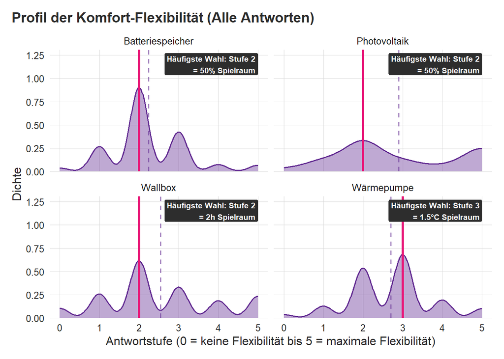

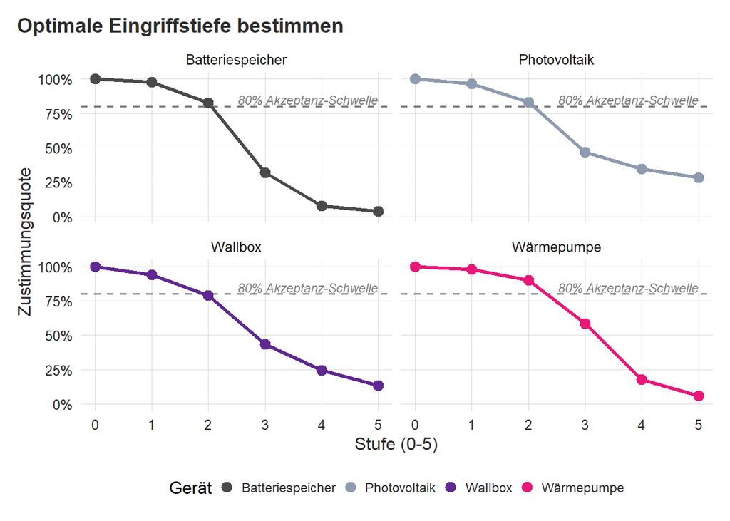

#### 3.7.2.1 Nach Steuerungshäufigkeit

[figure not shown]

[figure not shown]

### 3.7.3 Gerätebesitzer

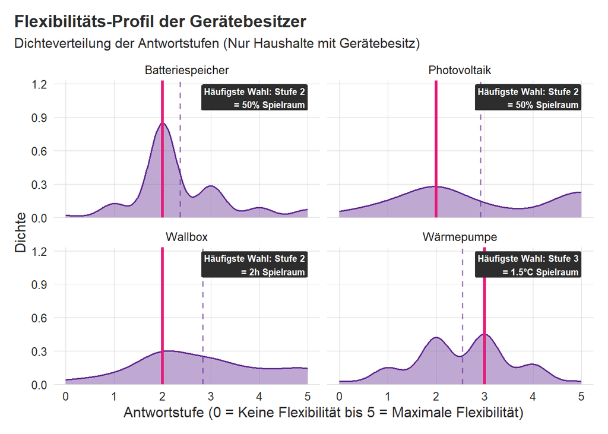

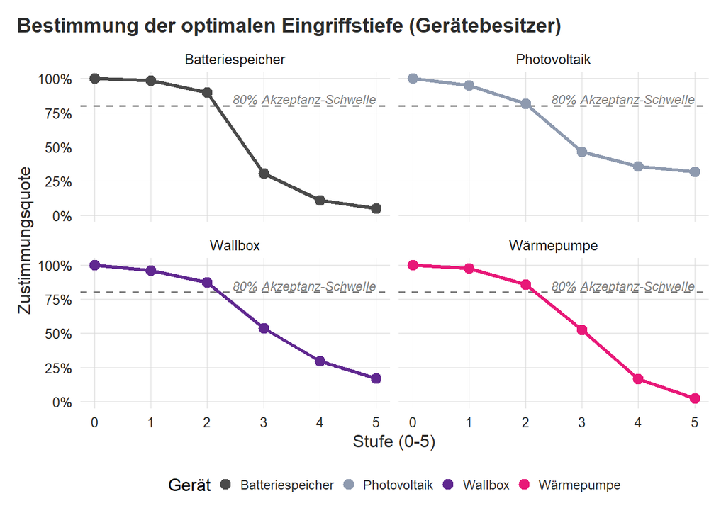

#### 3.7.3.1 Nach Steuerungshäufigkeit

[figure not shown]

[figure not shown]

## 3.8 Erwartete Vergütung

In diesem zentralen Abschnitt des Experiments wurde der jährliche Mindestbetrag (Willingness-to-Accept) ermittelt. Um realistische Werte zu erhalten, wurde ein „Cheap Talk Script“ eingesetzt und den Befragten ihre individuellen Komfort-Einschränkungen noch einmal unmittelbar vor der Preisabfrage vor Augen geführt.

**Item: Erwarteter jährlicher Mindestbetrag**

*“Als nächstes möchten wir wissen, welche Vergütung Sie für Ihre Teilnahme an der SURF-Plattform verlangen.”*

**Wichtiger Hinweis – Bitte realistisch einschätzen (Cheap Talk):**

- In ähnlichen Studien nennen Teilnehmer oft Beträge, die höher sind, als sie real akzeptieren würden.
- Bedenken Sie: Hohe Vergütungen müssten über die Netzentgelte von allen Haushalten finanziert werden.
- Bitte nennen Sie den Betrag, den Sie tatsächlich als fairen Ausgleich akzeptieren würden.

**Zusammenfassung Ihrer gewählten Einschränkungen:**

- *(Hier wurden dem Teilnehmer seine zuvor gewählten maximalen Einschränkungen für Wallbox, Wärmepumpe, Batteriespeicher und PV-Anlage individuell zusammengefasst eingeblendet.)*

**Die Preisschätzungsfrage:**

*“Wie hoch ist Ihr jährlicher Mindestbetrag, damit Sie **{RandFreq}-mal im Jahr** für jeweils 1–2 Stunden die automatische Steuerung Ihrer Geräte mit den genannten Einschränkungen akzeptieren?”*

**Antwortoptionen (Auswahl):**

- 0 € / 15 € / 30 € / 50 € / 75 € / 100 € / 125 € / 150 € / 175 € / 200 € / 250 €
- Mehr als 250 € (Betrag bitte angeben)
- Ich möchte nicht teilnehmen, egal wie hoch die Bezahlung ist.
- Weiß ich nicht / Sonstiges

| Entschädigung | Gesamt (n) | Gerätebesitzer (n) | Nicht-Besitzer (n) | Anteil (%) |
| --- | --- | --- | --- | --- |
| 0 € | 4 | 3 | 1 | 1.0% |
| 15 € | 13 | 6 | 7 | 3.3% |
| 30 € | 16 | 10 | 6 | 4.1% |
| 50 € | 61 | 40 | 21 | 15.5% |
| 75 € | 18 | 9 | 9 | 4.6% |
| 100 € | 69 | 40 | 29 | 17.6% |
| 125 € | 7 | 5 | 2 | 1.8% |
| 150 € | 24 | 12 | 12 | 6.1% |
| 175 € | 2 | 1 | 1 | 0.5% |
| 200 € | 14 | 8 | 6 | 3.6% |
| 250 € | 14 | 8 | 6 | 3.6% |
| Keine Angabe | 151 | 39 | 112 | 38.4% |

- Ein einzelner Befragter hat den Wert von 500 Euro angegeben (Nicht-Besitzer). Diese Angabe wir, aufgrund des Grades ihres Abweichung, zunächst als Ausreißer betrachtet.

Table 2

| Szenario | Status | n | Ø Betrag | Median | SD |
| --- | --- | --- | --- | --- | --- |
| 3-5 Eingriffe/Jahr | Gerätebesitzer | 50 | 96.80 € | 100 € | 67.03 |
|  | Nicht-Besitzer | 27 | 102.59 € | 100 € | 62.47 |
| 10-15 Eingriffe/Jahr | Gerätebesitzer | 53 | 88.77 € | 100 € | 55.65 |
|  | Nicht-Besitzer | 35 | 106.57 € | 100 € | 65.44 |
| 20-30 Eingriffe/Jahr | Gerätebesitzer | 39 | 95.38 € | 75 € | 60.16 |
|  | Nicht-Besitzer | 38 | 87.76 € | 75 € | 58.25 |
| Gesamtdurchschnitt | Gerätebesitzer | 142 | 93.42 € | 100 € | 60.76 |
|  | Nicht-Besitzer | 100 | 98.35 € | 100 € | 61.93 |

### 3.8.1 Nach Gerätebesitz

[figure not shown]

[figure not shown]

### 3.8.2 Nach Gerätetyp

[figure not shown]

[figure not shown]

- Diese Werte müssen als vorläufig gelten, da sie gleichzeitigen Besitz von Geräten nicht korrekt modellieren.
- Spätere Auswertungen werden den Besitzeffekt isolieren und so die Wirkung des Gerätebesitzes auf die Willingness-to-Accept (in Euro) statistisch isolieren.

### 3.8.3 Nach Steuerungshäufigkeit

[figure not shown]

[figure not shown]

## 3.9 Subjektive Sicherheit der erwarteten Vergütung

**Item: Sicherheit der Teilnahmebereitschaft**

*“Wie sicher sind Sie, dass Sie für den von Ihnen genannten Betrag tatsächlich an der SURF-Plattform teilnehmen würden?”*

**Antwortoptionen (Skala 0 bis 4):**

- 0 - Sehr unsicher (Reine Hypothese)
- 1 - Eher unsicher
- 2 - Teils, teils
- 3 - Eher sicher
- 4 - Sehr sicher (Ich würde unterschreiben)

Da die Abfrage der Entschädigungshöhe in einem hypothetischen Szenario erfolgte, wurde im Anschluss die Sicherheit dieser Angabe erhoben. Diese Variable dient als wichtiger Indikator für die Validität der monetären Forderungen: Eine hohe Sicherheit deutet darauf hin, dass die Befragten eine klare Vorstellung vom Wert ihres Komfortverzichts haben und die genannten Beträge weniger durch hypothetische Verzerrungen (Hypothetical Bias) beeinflusst sind. Die folgende Auswertung zeigt die Verteilung dieses Sicherheitsgefühls differenziert nach dem Adoptionsstatus.

Table 3

| Einschätzung der Sicherheit | Gesamt (n) | Besitzer (n) | Nicht-Besitzer (n) | Anteil (%) |
| --- | --- | --- | --- | --- |
| Sehr unsicher | 15 | 7 | 8 | 5.3% |
| Eher unsicher | 19 | 7 | 12 | 6.7% |
| Teils/Teils | 76 | 48 | 28 | 26.8% |
| Eher sicher | 141 | 83 | 58 | 49.6% |
| Sehr sicher | 33 | 17 | 16 | 11.6% |

[figure not shown]

### 3.9.1 Nach Steuerungshäufigkeit

[figure not shown]

In einem weiteren Analyseschritt wird untersucht, ob ein systematischer Zusammenhang zwischen der Höhe der geforderten Vergütung und der subjektiven Sicherheit der Angabe besteht. Durch die Segmentierung der Befragten in Sicherheitsgruppen (Unsicher [Sehr/eher unsicher], Teils/Teils, Sicher [Sehr/eher sicher]) lässt sich prüfen, ob ungesicherte Präferenzen zu extremeren Preisforderungen neigen oder ob sich bei hoher Angabesicherheit ein konsistenter ‘Marktpreis’ für die angebotene Flexibilität stabilisiert. Dies erlaubt eine präzisere Identifikation valider Preispunkte für das Anreizdesign.

[figure not shown]

Table 4

| Gruppe | Status | n | Ø Betrag |
| --- | --- | --- | --- |
| Unsicher | Gerätebesitzer | 9 | 127.78 € |
|  | Nicht-Besitzer | 15 | 130.00 € |
| Teils/Teils | Gerätebesitzer | 38 | 99.34 € |
|  | Nicht-Besitzer | 21 | 81.90 € |
| Sicher | Gerätebesitzer | 95 | 87.79 € |
|  | Nicht-Besitzer | 64 | 96.33 € |

## 3.10 Form und Struktur der Vergütung

Achtung: Dieser Block wird in der Umfrage, welche diesen Daten zugrunde liegt, vor der erwarteten Vergütung abgefragt. Aus diesem Grund kann das Ausmaß der erwarteten Vergütung nach der präferierten Vergütungsform und -struktur analysiert werden.

### 3.10.1 Form der Vergütung

Bevor die Höhe der Vergütung thematisiert wurde, wurde ermittelt, über welchen Kanal die Haushalte die Entschädigung am liebsten erhalten möchten. Dies ist entscheidend für die Ausgestaltung der Abrechnungsprozesse der Plattform.

**Item: Bevorzugte Form der Vergütung**

*“Wie möchten Sie für Ihre Teilnahme von der SURF-Plattform vergütet werden?”*

**Optionen:**

- Verringerung Ihrer jährlichen Stromrechnung
- Direkte Gutschrift auf Ihr Konto
- Bonuspunkte oder Gutscheine für Prämien
- Ich habe keine Präferenz

Table 5

| Präferenz (Label) | Gesamt (n) | Gerätebesitzer (n) | Nicht-Besitzer (n) | Anteil (%) |
| --- | --- | --- | --- | --- |
| Verringerung der jährlichen Stromrechnung | 130 | 71 | 59 | 43.5% |
| Direkte Gutschrift auf ihr Konto | 155 | 90 | 65 | 51.8% |
| Bonuspunkte oder Gutscheine für Prämien | 1 | 1 | 0 | 0.3% |
| Keine Präferenz | 13 | 11 | 2 | 4.3% |

[figure not shown]

### 3.10.2 Nach Steuerungshäufigkeit

[figure not shown]

#### 3.10.2.1 Erwartete Vergütung nach präferierter Vergütungsform

Table 6

| Vergütungsform | Status | n | Ø Betrag |
| --- | --- | --- | --- |
| Stromrechnung | Gerätebesitzer | 60 | 87.75 € |
|  | Nicht-Besitzer | 48 | 92.71 € |
|  | Gesamt | 108 | 89.95 € |
| Direktes Konto | Gerätebesitzer | 74 | 97.77 € |
|  | Nicht-Besitzer | 50 | 105.40 € |
|  | Gesamt | 124 | 100.85 € |
| Bonuspunkte | Gerätebesitzer | 1 | 100.00 € |
|  | Gesamt | 1 | 100.00 € |
| Keine Präferenz | Gerätebesitzer | 7 | 95.00 € |
|  | Nicht-Besitzer | 1 | 15.00 € |
|  | Gesamt | 8 | 85.00 € |

Table 7

| Vergütungsform | Status | n | Ø Betrag |
| --- | --- | --- | --- |
| Stromrechnung | Gerätebesitzer | 60 | 87.75 € |
|  | Nicht-Besitzer | 48 | 92.71 € |
|  | Gesamt | 108 | 89.95 € |
| Direktes Konto | Gerätebesitzer | 74 | 97.77 € |
|  | Nicht-Besitzer | 50 | 105.40 € |
|  | Gesamt | 124 | 100.85 € |
| Bonuspunkte | Gerätebesitzer | 1 | 100.00 € |
|  | Nicht-Besitzer | 0 | - |
|  | Gesamt | 1 | 100.00 € |
| Keine Präferenz | Gerätebesitzer | 7 | 95.00 € |
|  | Nicht-Besitzer | 1 | 15.00 € |
|  | Gesamt | 8 | 85.00 € |

[figure not shown]

### 3.10.3 Struktur der Vergütung

Ergänzend zur Auszahlungsform wurde die präferierte Vergütungslogik abgefragt. Hierbei standen verschiedene Modelle zur Auswahl, die sich im Grad der Leistungsorientierung (pauschal vs. nutzungsabhängig) unterscheiden.

**Item: Gewünschte Struktur der Vergütung**

*“Wofür möchten Sie im Rahmen der SURF-Plattform finanziell vergütet werden?”*

**Optionen:**

- Nur für die Teilnahme (alle erhalten denselben Betrag, unabhängig davon, wie viel Flexibilität sie beigetragen haben)
- Nur für die tatsächliche Menge bereitgestellter Flexibilität (nur wer mehr beiträgt, erhält auch mehr Geld)
- Für die Teilnahme und die Menge der bereitgestellten Flexibilität (alle erhalten einen Grundbetrag, wer mehr beiträgt, erhält jedoch auch mehr zusätzliches Geld)
- Ich habe keine Präferenz

Table 8

| Struktur (Label) | Gesamt (n) | Gerätebesitzer (n) | Nicht-Besitzer (n) | Anteil (%) |
| --- | --- | --- | --- | --- |
| Jährlicher Fixbetrag | 8 | 4 | 4 | 2.7% |
| Betrag pro Steuerungseingriff | 89 | 50 | 39 | 30.1% |
| Kombination aus beidem | 185 | 106 | 79 | 62.5% |
| Keine Präferenz | 14 | 12 | 2 | 4.7% |

[figure not shown]

[figure not shown]